# Intial Grouped Feature Importance (Deep EESNs)

Group Feature Importance from Intial Tuned Models

Author

Jacob Johnson and Katherine Goode

Published

May 11, 2026

Quarto document to summarize the feature importance results from the models with the best RMSE from the tuning done in 01:

- Loads feature importance results
- Joins and save feature importance results
- Plots feature importance

# Set Up

Load packages:

```r
library(dplyr)
library(ggplot2)
library(purrr)
library(stringr)
library(gridExtra)
library(tidyr)
library(wesanderson)
```

Specify file path:

```r
#fp = "~/../../Volumes/subseasonal_extreme/"
fp_data = "../data/"
fp_results = "../results/"
```

# Data Steps

Variables identified by Maike as redundant:

```r
redundant_cols <-
  c(
    'slp_weekave_atlantic_ocean_mean',
    'h_850_weekave_conus_mean',
    'h_850_weekave_atlantic_ocean_pc4',
    'h_850_weekave_mexico_gulf_mean',
    'slp_weekave_mexico_gulf_mean',
    'slp_weekave_conus_pc1',
    'ts_weekave_conus_pc1',
    'slp_weekave_atlantic_trop_mean',
    'ts_weekave_southern_canada_pc1',
    't_850_weekave_southern_canada_mean',
    'h_850_weekave_atlantic_ocean_pc5',
    'slp_weekave_atlantic_ocean_pc6',
    'h_500_weekave_pacific_trop_mean',
    'h_850_weekave_atlantic_trop_mean',
    't_500_weekave_pacific_trop_mean',
    't_500_weekave_atlantic_trop_pc1',
    'h_850_weekave_pacific_ocean_pc1',
    't_850_weekave_conus_pc1',
    'slp_weekave_atlantic_ocean_pc1',
    'slp_weekave_pacific_trop_mean',
    't_850_weekave_southern_canada_pc1',
    'h_850_weekave_arctic_pc1',
    'h_500_weekave_atlantic_trop_mean',
    'h_850_weekave_atlantic_ocean_pc2',
    'slp_weekave_atlantic_ocean_pc3',
    'h_850_weekave_atlantic_ocean_pc7',
    't_500_weekave_mexico_gulf_mean',
    't_500_weekave_southern_canada_pc1',
    'slp_weekave_pacific_trop_pc2',
    'h_850_weekave_arctic_mean',
    'ts_weekave_atlantic_trop_mean',
    'h_850_weekave_pacific_trop_mean'
  )
```

Load climate inputs:

```r
climate_inputs <-
  readr::read_csv(
    paste0(
      fp_data,
      "weekly_aves_regional_inputs_1980_2020.csv"
    ),
    show_col_types = FALSE
  ) |>
  mutate(date = as.character(date)) |>
  separate(date, into = c("year", "week"), sep = 4, remove = FALSE) |>
  mutate(
    year = as.numeric(year),
    week = as.numeric(week)
  ) |>
  select(-all_of(redundant_cols))
```

Prepared variable names to attach to feature importance results (warning is okay and is due to separation of variable with different lengths):

```r
input_vars <-
  data.frame(var = c(names(climate_inputs)[-c(1:3)], "temp")) |>
  mutate(var = str_remove(var, "weekave_")) |>
  separate(
    var,
    into = c("var1", "var2", "var3", "var4", "var5"),
    remove = FALSE
  ) |>
  rename(climate_var = var1) |>
  mutate(
    climate_var = ifelse(
      var2 %in% c("500", "850"),
      paste0(climate_var, var2),
      climate_var
  )) |>
  mutate(
    var2 = ifelse(
      var2 %in% c("500", "850"),
      NA,
      var2
  )) |>
  rename(input_region = var2) |>
  mutate(
    var6 = ifelse(
      str_detect(var3, "pc"),
      var3,
      ifelse(
        str_detect(var3, "mean"),
        var3,
        NA
      )
    )
  ) |>
  mutate(
    var3 = ifelse(
      str_detect(var3, "pc"),
      NA,
      ifelse(
        str_detect(var3, "mean"),
        NA,
        var3
      )
    )
  ) |>
  mutate(
    input_region = ifelse(
      is.na(var3),
      input_region,
      ifelse(
        is.na(input_region),
        var3,
        paste0(input_region, "_", var3)
      )
  )) |>
  select(-var3) |>
  mutate(
    var7 = ifelse(
      str_detect(var4, "pc"),
      var4,
      ifelse(
        str_detect(var4, "mean"),
        var4,
        NA
      )
    )
  ) |>
  mutate(
    var4 = ifelse(
      str_detect(var4, "pc"),
      NA,
      ifelse(
        str_detect(var4, "mean"),
        NA,
        var4
      )
    )
  ) |>
  mutate(
    input_region = ifelse(
      is.na(var4),
      input_region,
      ifelse(
        is.na(input_region),
        var4,
        paste0(input_region, "_", var4)
      )
  )) |>
  select(-var4) |>
  rename(stat = var5) |>
  mutate(
    stat = ifelse(
      is.na(stat) & is.na(var6),
      var7,
      ifelse(
        is.na(stat) & is.na(var7),
        var6,
        stat
      )
  )) |>
  select(-var6, -var7) |>
  mutate(
    input_region = ifelse(is.na(input_region), "temp", input_region),
    stat = ifelse(is.na(stat), "temp", stat)
  ) |>
  mutate(var_id = 1:n()) |>
  select(var_id, everything())
```

# FI Results

Determine files containing ESN feature importance results:

```r
fi_fp = paste0(fp_results, "gpfi-nreps01/")
fi_files = list.files(fi_fp)
fi_files = fi_files[str_detect(fi_files, "targetregion")]
```

Load in groups from Maike:

```r
`%ni%` <- Negate(`%in%`)
clusters <-
  readr::read_csv(paste0(
    fp_data,
    "All_GPFI_Merged.csv"
  )) |>
  select(Group, Feature, Region, Horizon) |>
  mutate(middle = substr(Feature, 3, 6)) |>
  filter(middle %ni% c("_lag", "lag_")) |>
  select(-middle)
```

Join Feature Importance with Groups

```r
input_vars_with_groups <-
  clusters |>
  mutate(var = str_remove_all(Feature, "_weekave")) |>
  rename(tau = Horizon,
         region = Region) |>
  left_join(input_vars, by="var") |>
  select(-Feature, -var_id)
```

Load ESN feature importance results:

```r
fi_df <-
  set_names(fi_files) |>
  map(
    .f = function(x)
      read.csv(paste0(fi_fp, x)) |> mutate(Group = 1:n())
  ) |>
  list_rbind(names_to = "file") |>
  mutate(file = str_remove(file, ".csv")) |>
  separate(file, into = c("region", "tau", "m", "nlayers", "nh", "nu")) |>
  mutate(
    region = str_remove(region, "targetregion"),
    tau = as.numeric(str_remove(tau, "tau")),
    m = as.numeric(str_remove(m, "m")),
    nlayers = as.numeric(str_remove(nlayers, "nlayers")),
    nh = as.numeric(str_remove(nh, "nh")),
    nu = as.numeric(str_remove(nu, "nu")),
    fi = -fi
  ) |>
  left_join(input_vars_with_groups, by = c("Group", "tau", "region")) |>
  filter(!is.na(fi)) |>
  select(region:nu, Group:stat, fi)
```

Create ordered version of feature importance:

```r
fi_ordered <-
  fi_df |>
  group_by(region, tau) |>
  arrange(region, tau, desc(fi)) |>
  mutate(rank = dense_rank(desc(fi))) |>
  ungroup()
```

Save data:

```r
write.csv(
  fi_ordered,
  paste0(
    fp_results,
    "gpfi-initial.csv"
  ),
  row.names = FALSE
)
```

## Most important Groups by Region and Horizon

```r
## Subtitles
subtitles <-
  fi_df |>
  summarise(
    m = mean(m),
    nlayers = mean(nlayers),
    nu = mean(nu),
    nh = mean(nh),
    .by = c(region, tau)
  ) |>
  mutate(
    st = paste0(
      "m:", m,
      " nlayers:", nlayers,
      " nu:", nu,
      " nh:", nh)
  )

## Vars in Groups
groupvars <-
  fi_df |>
  group_by(region, tau, Group) |>
  summarise(groupvars = paste(var, collapse = ",\n"))
```

```
`summarise()` has regrouped the output.
ℹ Summaries were computed grouped by region, tau, and Group.
ℹ Output is grouped by region and tau.
ℹ Use `summarise(.groups = "drop_last")` to silence this message.
ℹ Use `summarise(.by = c(region, tau, Group))` for per-operation grouping
  (`?dplyr::dplyr_by`) instead.
```

```r
## Ordered df
fi_ave_ordered <-
  fi_ordered |>
  summarise(
    fi_ave = mean(fi),
    fi_min = min(fi),
    fi_max = max(fi),
    .by = c(region, tau, Group)
  ) |>
  group_by(region, tau) |>
  arrange(tau, desc(fi_ave)) |>
  mutate(rank = dense_rank(desc(fi_ave))) |>
  ungroup() |>
  left_join(subtitles, by=c("region", "tau")) |>
  left_join(groupvars, by=c("region", "tau", "Group"))

## Max FI
fi_max <-
  fi_ave_ordered |>
  na.omit() |>
  group_by(region) |>
  summarise(plot_max = max(fi_ave, na.omit=F))
```

#### MW

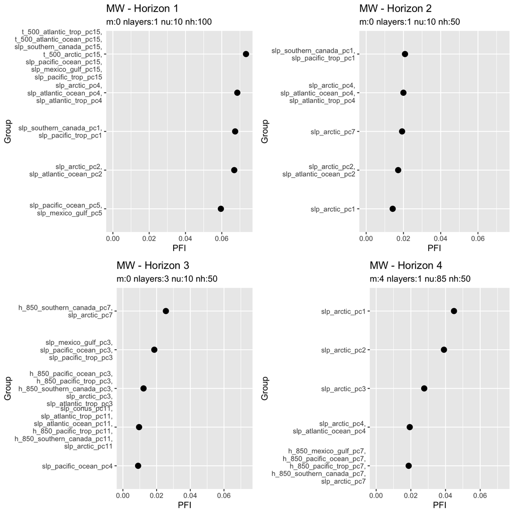

#### NE

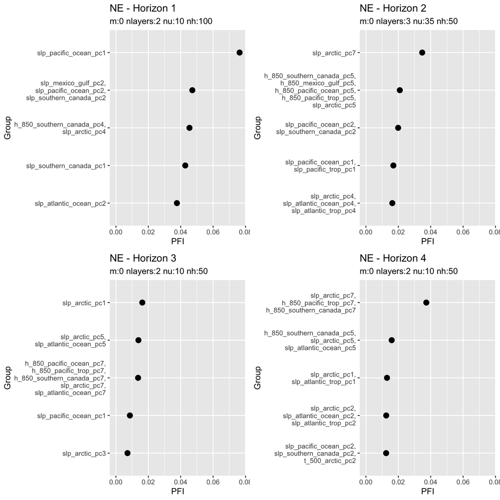

#### SE

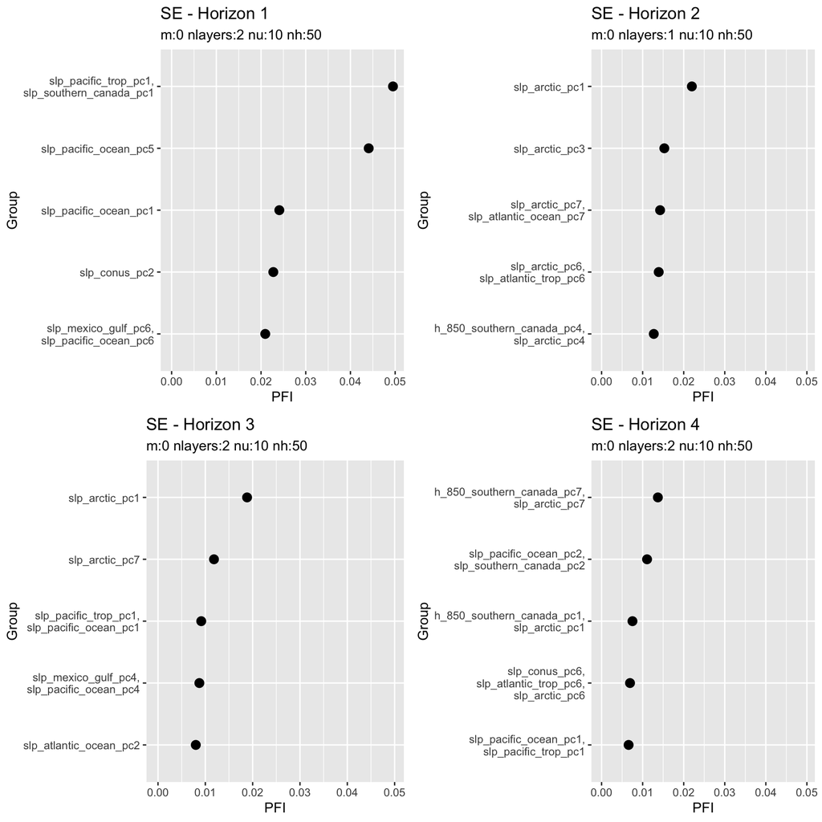

#### SW

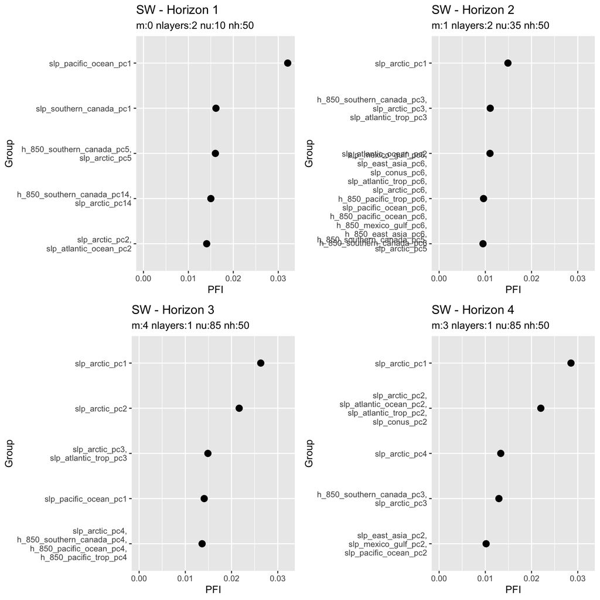

#### W

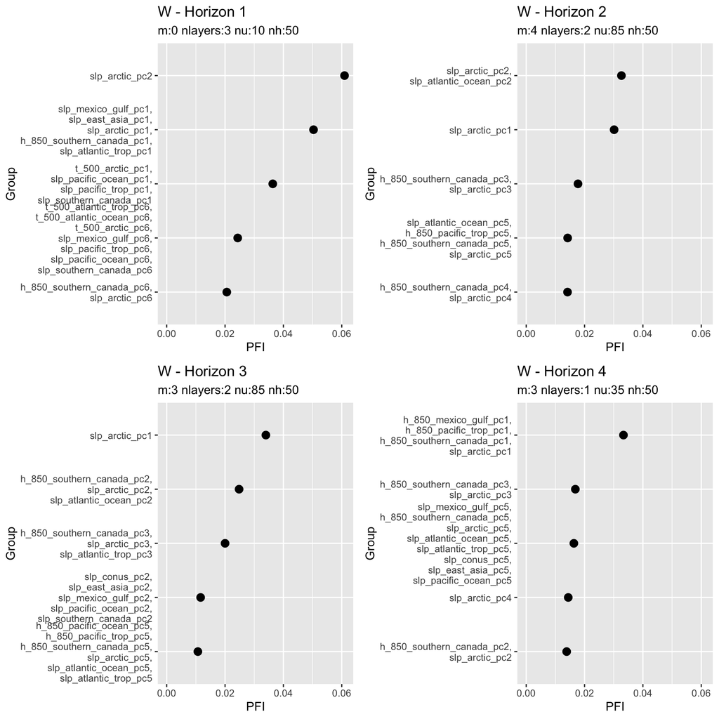

#### Averaged (over forecast region)

Compute average FI for each forecast horizon and input variable (averaged over forecast region):

```r
fi_ave_ordered <-
  fi_ordered |>
  summarise(
    fi_ave = mean(fi),
    fi_min = min(fi),
    fi_max = max(fi),
    .by = c(tau, var)
  ) |>
  group_by(tau) |>
  arrange(tau, desc(fi_ave)) |>
  mutate(rank = row_number()) |>
  ungroup()
```

Extract the 25 variables with the highest average feature importance (for each horizon):

```r
fi_ave_ordered_sub1 <-
  fi_ave_ordered |>
  filter(rank <= 25, tau == 1) |>
  mutate(rank = factor(rank, levels = 25:1))

fi_ave_ordered_sub2 <-
  fi_ave_ordered |>
  filter(rank <= 25, tau == 2) |>
  mutate(rank = factor(rank, levels = 25:1))

fi_ave_ordered_sub3 <-
  fi_ave_ordered |>
  filter(rank <= 25, tau == 3) |>
  mutate(rank = factor(rank, levels = 25:1))

fi_ave_ordered_sub4 <-
  fi_ave_ordered |>
  filter(rank <= 25, tau == 4) |>
  mutate(rank = factor(rank, levels = 25:1))
```

Plots of average FI plus/minus minimum and maximum FI values (averaged over forecast region):

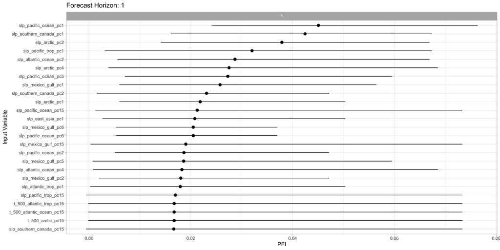

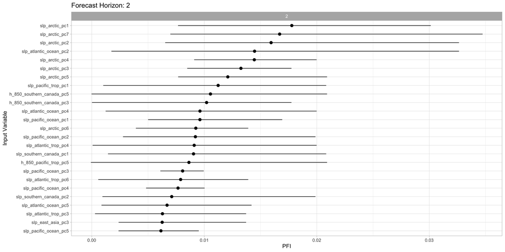

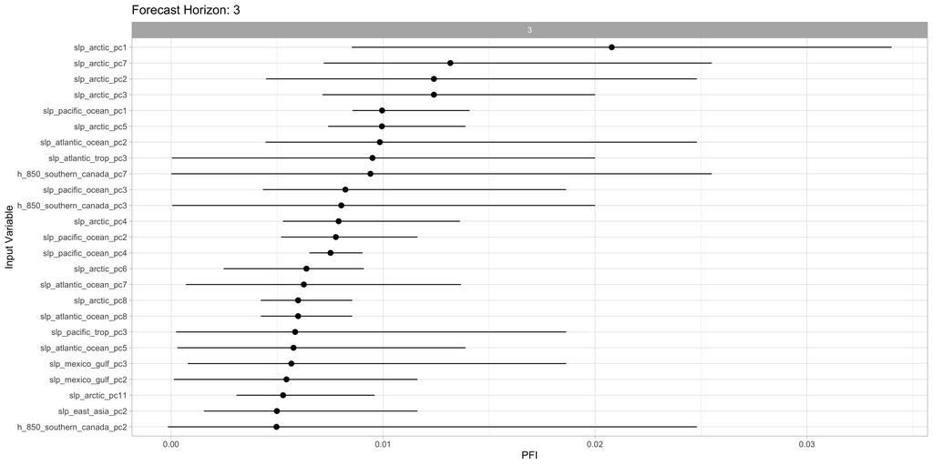

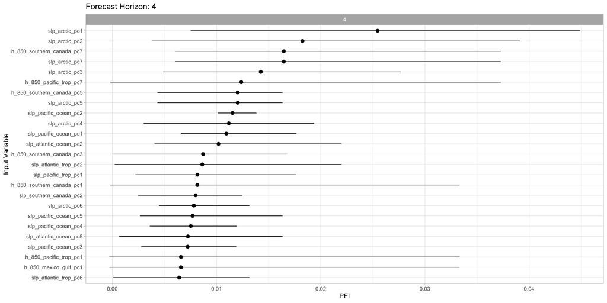

## Averaged (over forecast region, input region, and stat)

Compute average FI by forecast horizon and input climate variable:

```r
fi_ordered_ave_by_tau_climvar <-
  fi_ordered |>
  summarise(
    fi_ave = mean(fi),
    fi_min = min(fi),
    fi_max = max(fi),
    .by = c(tau, climate_var)
  ) |>
  group_by(tau) |>
  arrange(tau, desc(fi_ave)) |>
  mutate(rank = row_number()) |>
  ungroup()
```

Extract the 25 variables with the highest average feature importance (for each horizon):

```r
fi_ordered_ave_by_tau_climvar_sub1 <-
  fi_ordered_ave_by_tau_climvar |>
  filter(rank <= 25, tau == 1) |>
  mutate(rank = factor(rank, levels = 25:1))

fi_ordered_ave_by_tau_climvar_sub2 <-
  fi_ordered_ave_by_tau_climvar |>
  filter(rank <= 25, tau == 2) |>
  mutate(rank = factor(rank, levels = 25:1))

fi_ordered_ave_by_tau_climvar_sub3 <-
  fi_ordered_ave_by_tau_climvar |>
  filter(rank <= 25, tau == 3) |>
  mutate(rank = factor(rank, levels = 25:1))

fi_ordered_ave_by_tau_climvar_sub4 <-
  fi_ordered_ave_by_tau_climvar |>
  filter(rank <= 25, tau == 4) |>
  mutate(rank = factor(rank, levels = 25:1))
```

Plots of average FI plus/minus minimum and maximum FI values (averaged over forecast region):

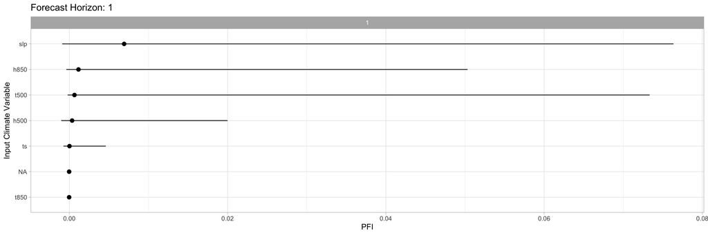

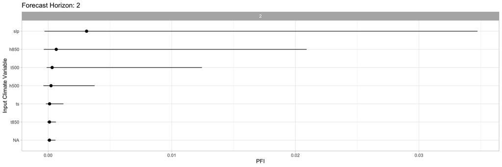

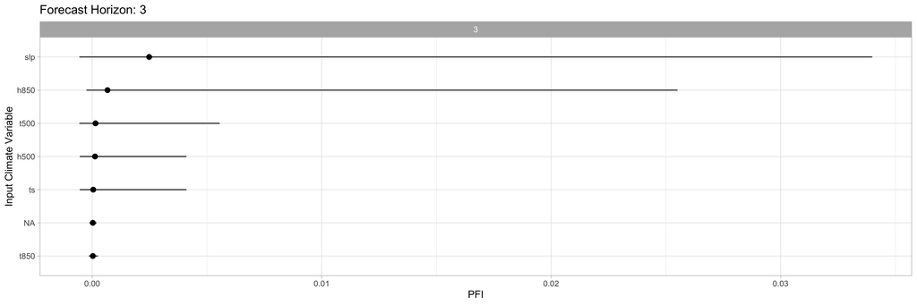

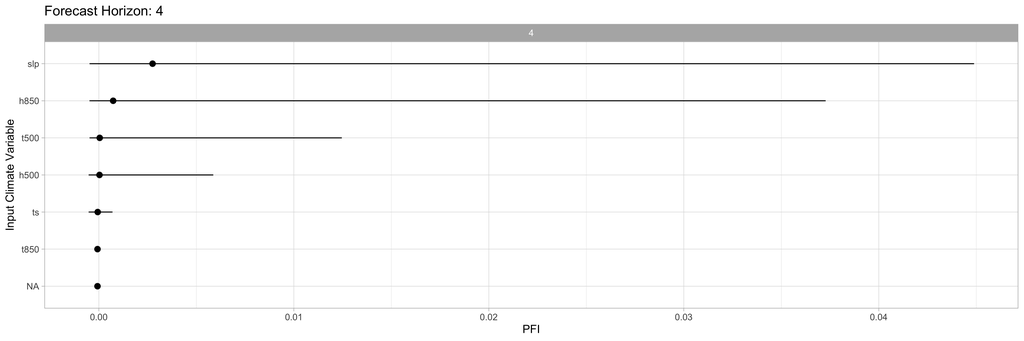

## FI by Variable

Input region:

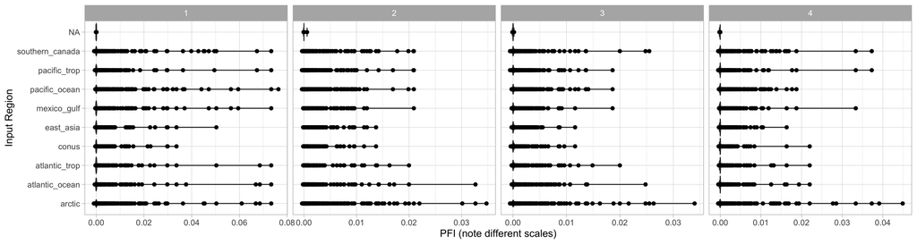

Statistic:

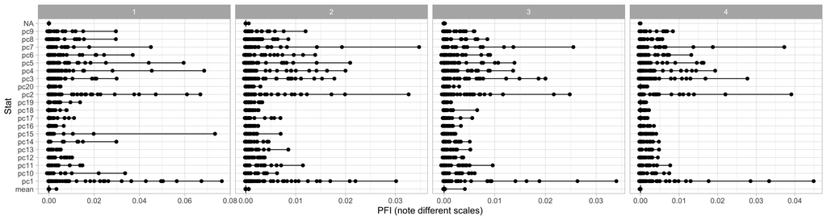

Forecast region:

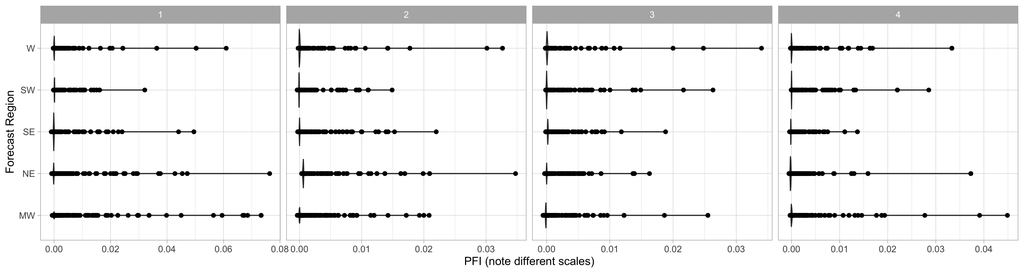

Climate variable:

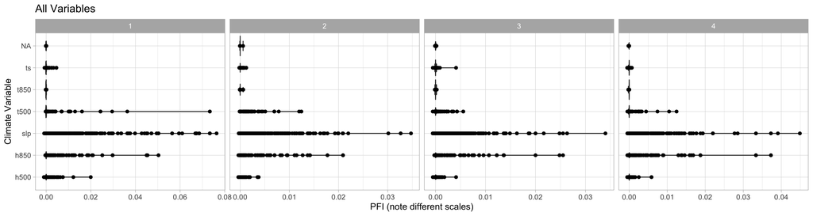

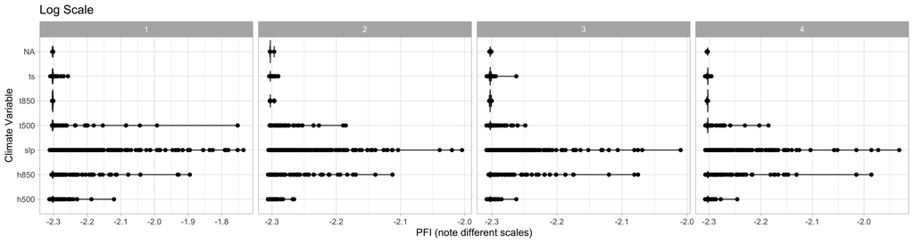

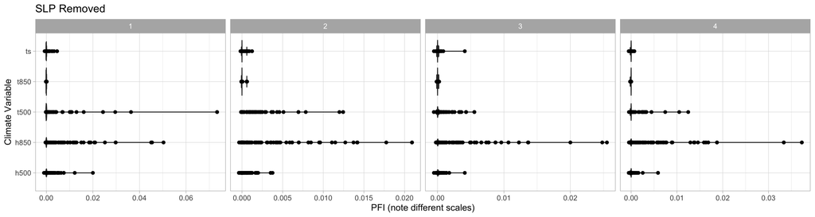

## Top 100

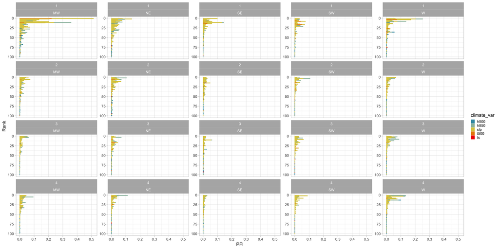

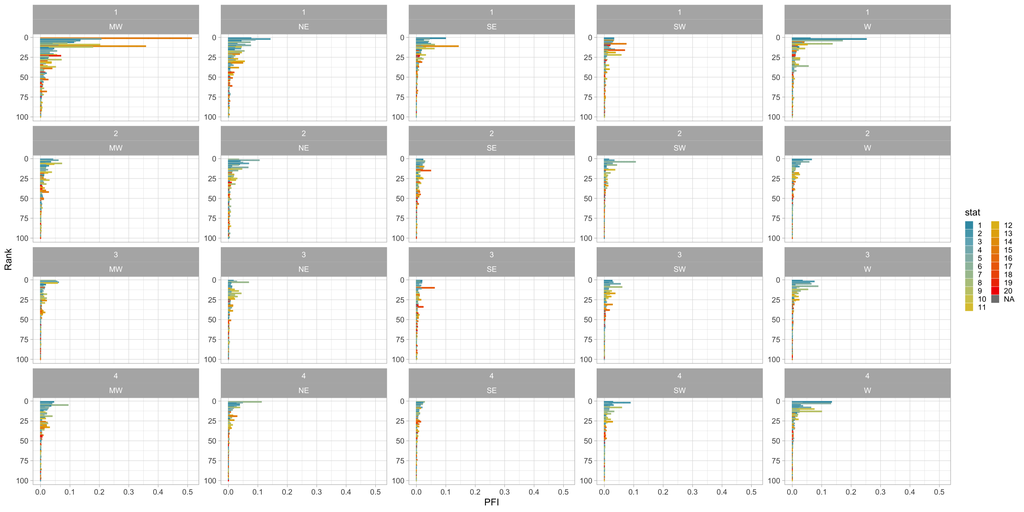

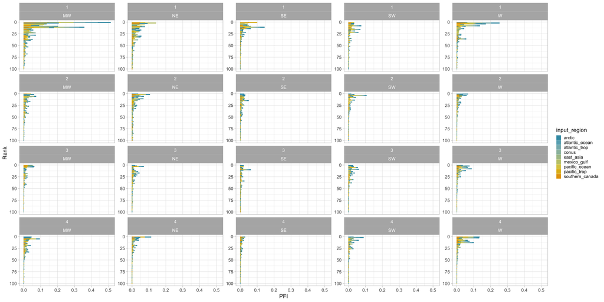

## Top 50

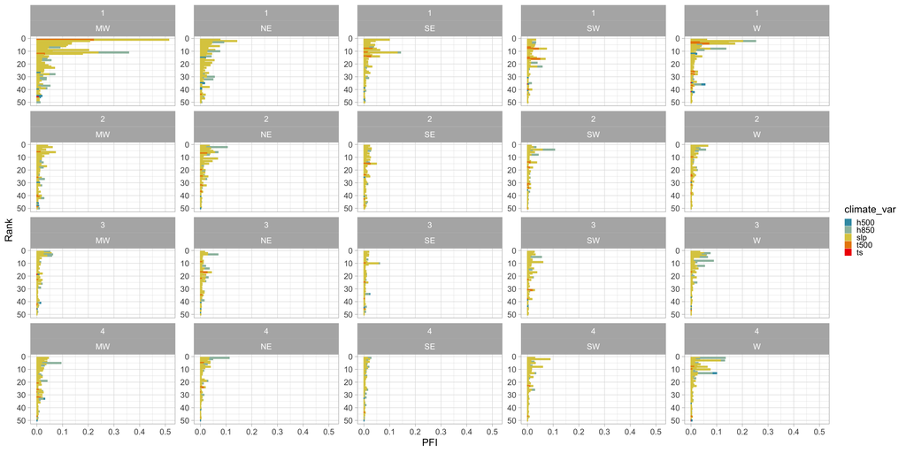

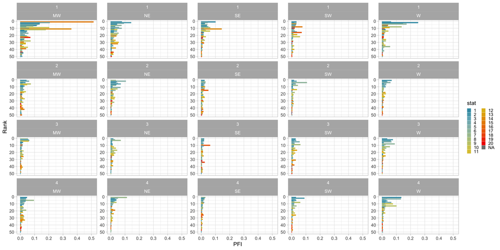

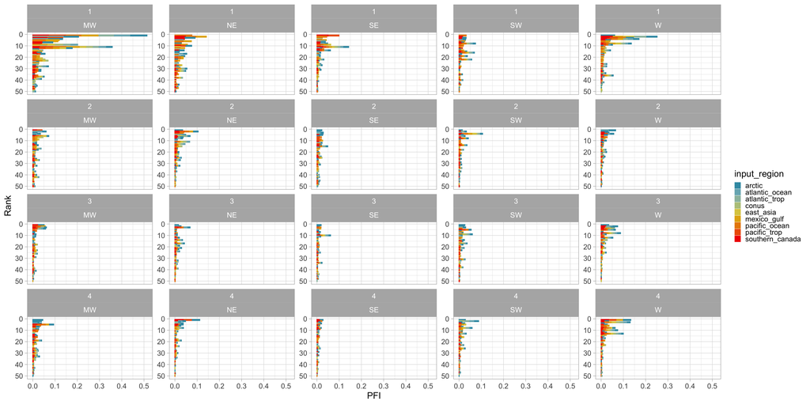

## Top 25

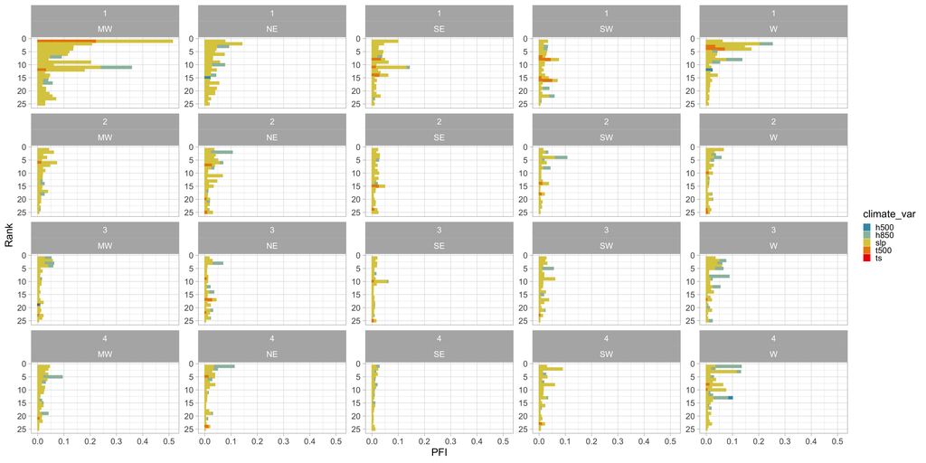

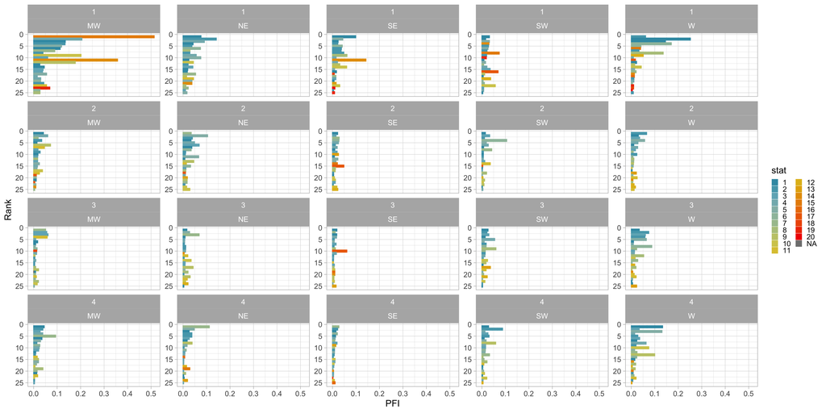

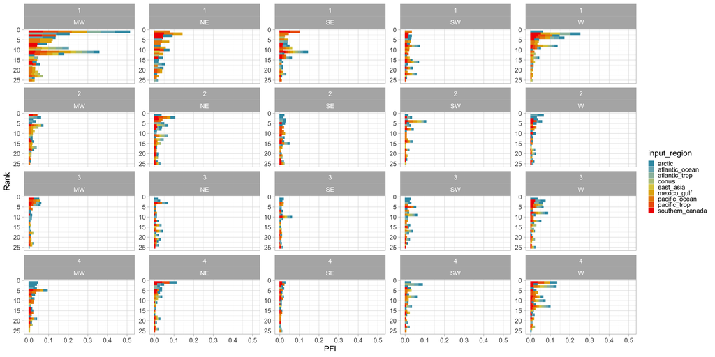

## Top 100 (marginal)

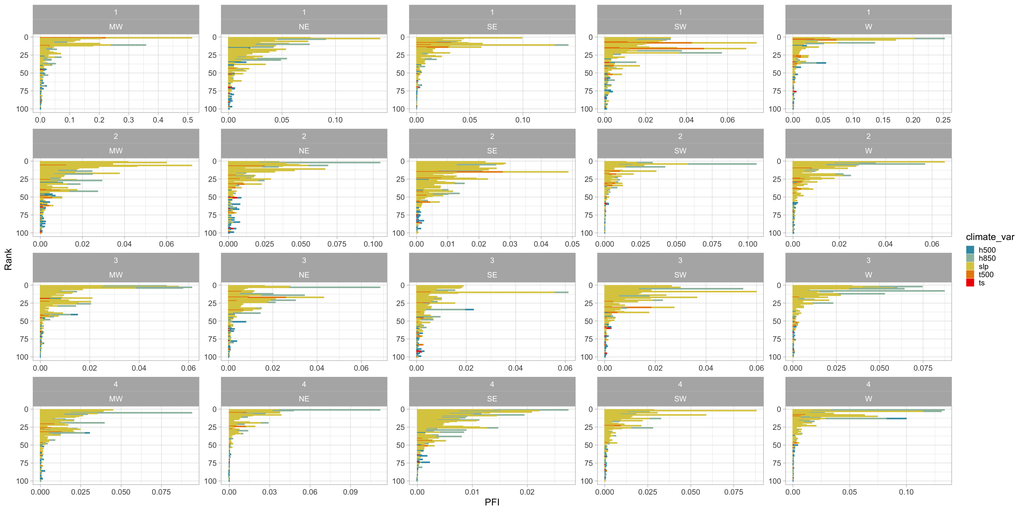

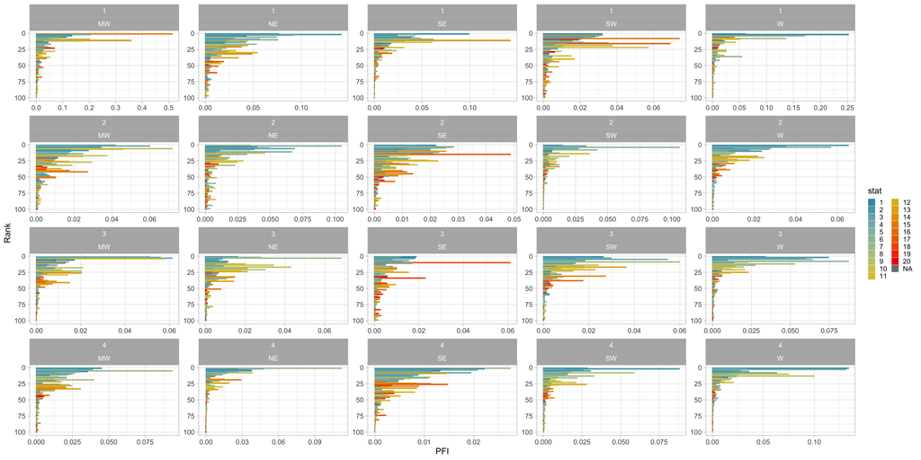

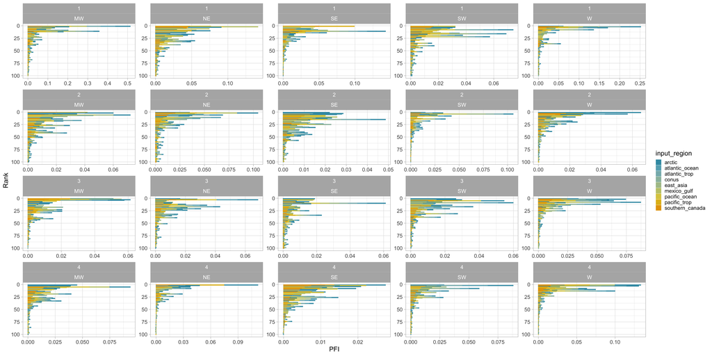